# STAT 413/613 Lab 1: Git and GitHub

Richard Ressler

2020-06-19

# Instructions

- Save, add, and commit after answer each numbered question.
- Push to GitHub when you are done.

## Learning Outcomes

- Apply material from STAT 412/612
- Commit code to a Git repo and push to GitHub.

# College Scorecard

The data folder contains “college_score_19-12-12.csv”, a subset of the data in the [College Scorecard](https://collegescorecard.ed.gov/data/) database as of 12-12-2019. These data contain information on colleges in the United States. The variables include:

- `UNITID` and `OPEID`: Identifiers for the colleges.
- `INSTNM`: Institution name
- `ADM_RATE`: The Admission Rate.
- `SAT_AVE`: Average SAT equivalent score of students admitted.
- `UGDS`: Enrollment of undergraduate certificate/degree-seeking students
- `COSTT4_A`: Average cost of attendance (academic year institutions)
- `AVGFACSAL`: Average faculty salary
- `GRAD_DEBT_MDN`: The median debt for students who have completed
- `AGE_ENTRY`: Average age of entry
- `ICLEVEL`: Level of institution (1 = 4-year, 2 = 2-year, 3 = less than 2-year).
- `MN_EARN_WNE_P6`: Mean earnings of students working and not enrolled 6 years after entry.
- `MD_EARN_WNE_P6`: Median earnings of students working and not enrolled 6 years after entry.
1. Use relative paths to load the data frame from college_score.csv.
2. If you used the default settings for reading in the data, then multiple variables are probably characters when they should be numerics. Which ones? Why were they read in as characters? Fix these variables to be numbers.
3. Does average faculty salary seem to be associated the mean earnings of students six years after graduating? Justify with an appropriate plot.
4. Does the level of the institution seems to be associated with the mean earnings of students six years after graduating? Reproduce this plot in R to explore this relationship (Hint: use factors):

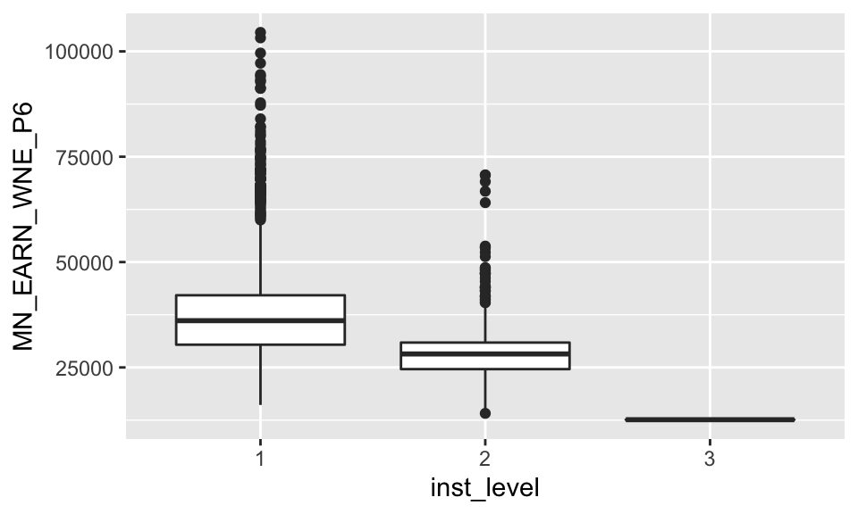

5. Is the length of the name of an institution (in number of **characters**) associated with the mean earnings six years after graduation? Justify with an appropriate plot with name length on the vertical (Y) axis.
6. Is the length of the name of an institution (in number of **words**) associated with the mean earnings six years after graduation? Justify with an appropriate plot. Make sure you appropriately account for overplotting if this is an issue.
7. What are the shortest- and longest-named institutions (in terms of number of characters)? Try doing this in one `filter()` call.
8. Devise your own ranking of level 1 universities. Which ones are the best/worst under your ranking? Where does American University rank?